# Prosjektoppgave Fysikk 2 - Den lykkeligste tanken

Av: Filippa, Maja og Lisa

I 1915 lanserte Einstein den generelle relativitetsteorien, og denne forståelsen av tid, rom og gravitasjon endret fysikernes forståelse av sammenhengen mellom disse. Under utformingen av teorien viste Einstein at lyset krummes rundt massive objekter, som for eksempel sola, og denne teorien ble bevist av den britiske fysikeren Arthur Eddington i 1919. Denne artikkelen skal undersøke forskningsspørsmålet “Hvordan påvirker masse og tidrom lyset?”, og se nærmere på den generelle relativitetsteorien. Artikkelen presenterer også en forenklet modell av lysets krumning i tidrommet.

### Teori

Einsteins generelle relativitetsteori er en teori om gravitasjon. Teorien ble utformet som en konsekvens av Einsteins tidligere teori, som i dag blir kalt den spesielle relativitetsteorien. Det spesielle relativitetsprinsippet, bygger på Einsteins postulater:

1. Fysikkens lover har samme form i alle treghetssystemer.
2. Lysfarten i vakuum har samme verdi i alle treghetssystemer.

For den spesielle relativitetsteorien anses et treghetssystem som et referansesystem der Newtons første lov gjelder. Ifølge Einsteins postulater har lysfarten i vakuum samme verdi i alle treghetssystemer. Lyset er bygget opp av elementærpartikkelen foton. Fotoner bærer på energi, men har ingen masse. For gjenstander med masse er bevegelsesmengden gitt ved:

$$p=mv$$

Dersom gjenstanden oppnår en fart som er større enn 10% av lysfarten c, må man regne relativistisk. Lysfarten i vakuum er gitt ved $c=3*10^8m/s$. Den relativistiske bevegelsmengden er da gitt ved:

$$p=\gamma mv$$

Der $\gamma$ er Lorentzfaktoren, gitt ved:

$$\gamma = \frac{1}{\sqrt{1-(\frac{v}{c})^2}}$$

Når v nærmer seg c, vil nevneren i Lorentzfaktoren gå mot null, og Lorentzfaktoren vil gå mot uendelig. Bevegelsesmengden til gjenstanden vil da bli uendelig stor, noe som betyr at det vil kreves en uendelig stor kraft for å akselerere gjenstanden nærmere lysfarten. Dette tilsier at ingenting kan oppnå en høyere fart enn lyset (Callin, et al., 2022).

[figure not shown]

Bilde 1. Relativistisk bevegelsesmengde. Ergo Fysikk 2. s.179 (Callin et al., 2022)

I den spesielle relativitetsteorien definerer Einstein treghetssystemet som et referansesystem der treghetsloven gjelder, altså at summen av kreftene i systemet er lik null (Callin, et al., 2022). Dette betyr at systemet har konstant eller ingen fart. Et legeme i fritt fall vil ikke oppleve å bli påvirket av noen krefter, på samme måte som i et treghetssystem. Dette kalles ekvivalensprinsippet, og gir grunnlaget for en utvidelse av treghetssystemets definisjon i det generelle relativitetsprinsippet. Ifølge Einstein er et referansesystem i fritt fall også et treghetssystem dersom gravitasjonsfeltet er homogent. I et homogent gravitasjonsfelt vil akselerasjonen være konstant. For å kunne beskrive inhomogene gravitasjonsfelt har den generelle relativitetsteorien også utvidet relativitetsprinsippet der fysikkens lover har samme form i alle referansesystemer, ikke bare treghetssystemer i homogene gravitasjonsfelt (Callin, et al., 2022).

På 1600-tallet omtalte Newton gravitasjon som en kraft som virker mellom objekter med masse. Denne gravitasjonsteorien var ikke forenelig med Einsteins spesielle relativitetsteori. Dersom sola plutselig forsvinner, vil man oppleve denne endringen momentant på jorda. Ifølge den spesielle relativitetsteorien er det ingenting som kan reise raskere enn lyset – ikke engang krefter mellom legemer. Einstein konkluderte dermed med at gravitasjon ikke kan være en kraft, og han definerte det heller som en geometrisk egenskap til selve rommet rundt legemer – tidrommet. Denne nye teorien om gravitasjon er en del av den generelle relativitetsteorien (Callin, et al., 2022).

**Geometrisk eksempel**

Det at gravitasjon påvirker tidrommet kan forklares med et geometrisk eksempel:

1. To objekter blir sendt parallelt bortover på et plan. Dersom ingen ytre krefter utfører et arbeid på objektene, vil de fortsette i samme retning.

[figure not shown]

Bilde 2: [Kilde](https://titan.uio.no/blogg/2020/gravitasjon-er-krummet-tid-og-rom)

1. De to objektene sendes først parallelt ut på planet, før så å gradvis bevege seg mot hverandre til de møtes. Med gravitasjonsteorien til Newton, ville forklaringen på denne bevegelsen vært at det virker en tiltrekningskraft mellom de to objektene. I Einsteins generelle relativitetsteori regnes ikke gravitasjon som en kraft, men heller en egenskap ved tidrommet. Bevegelsen til de to objektene kan også forklares med denne teorien.

[figure not shown]

Bilde 3: [Kilde](https://titan.uio.no/blogg/2020/gravitasjon-er-krummet-tid-og-rom)

1. Tidligere antok man at de to objektene beveget seg langs et rett plan. Dersom de to objektene følger en rett linje langs et krummet plan, vil man oppleve at de først starter parallelt, før de skråner inn mot hverandre og møtes. Det samme vil skje med lengdegradene på jorda. På et kart vil linjene være parallelle, mens på en globus møtes de i polene. I begge tilfellene følger linjene en rett bane.

[figure not shown]

Bilde 4: [Kilde](https://titan.uio.no/blogg/2020/gravitasjon-er-krummet-tid-og-rom)

Det generelle relativitetsprinsippet bruker dermed geometrien til tidrommet for å motbevise Newtons gravitasjonsteori ved å forklare hvordan objekter kan oppleve gravitasjon uten at det fungerer tiltrekningskrefter mellom dem. De to objektene i eksempelet ovenfor kolliderer som et resultat av krumningen i overflaten de beveger seg på, og ikke fordi de trekkes mot hverandre (Andersen, 2020).

I sin generelle relativitetsteori beskrev Einstein gravitasjon som et resultat av at massive objekter, som planeter eller stjerner, krummer tidrommet rundt dem. Denne krumningen fungerer som en slags nedoverbakke som heller inn mot legemet, og jo større masse legemet har, desto brattere blir bakken. Solen, med sin masse på 333 000 jordmasser, skaper altså en større krumning i tidrommet enn det jorden gjør. Når solen går i bane rundt jorden, er det ikke fordi det oppstår tiltrekningskrefter mellom de to himmellegemene, men heller fordi tidrommet i seg selv er krummet rundt solen. Det samme gjelder gravitasjonen på jorden. En fallskjermhopper i fritt fall vil oppleve å bli «trukket» ned mot bakken fordi hun beveger seg langs en nedoverbakke jorden har skapt i tidrommet (Buanes, 2015).

[figure not shown]

Bilde 5: [Kilde](https://uh.edu/~jclarage/astr3131/lectures/4/einstein/Einstein_stanford_Page7.html)

**Krumning av lyset**

[figure not shown]

Bilde 6: [Kilde](https://weinsteing.wordpress.com/2017/12/20/the-geodesics-of-the-schwarzschild-metric-5/)

### Modellering

Det finnes mange ulike modeller som forsøker å visualisere krumningen av tidrom. Man kan lage en forenklet modell av påvirkningen ulike himmellegemers masse har på avbøyingen av lyset ved bruk av et laken og kuleformede masser.

**Utstyrsliste:**

- Laken
- Målebånd
- Gaffateip
- Skråplan
- Vekt
- Omløpslegeme
  - Klinkekule
- Sentrallegemer av ulik masse
  - Innebandyball
  - Boccia-ball
  - Appelsin
  - Fotball
  - Mango
- Selfie-stang/tripod med kamera

**Metode**

1. Strekk et laken ut over et kvadratisk område over bakken og mål sidelengdene. Bruk teip eller tau til å binde opp lakenet.
2. Bruk et skråplan for å gi klinkekulen en fast utgangsfart og vinkel. Pass på at skråplanet er festet godt slik at det ikke beveger seg mellom hver gjennomføring.
3. Plasser et kuleformet objekt i midten av lakenet og bruk skråplanet til å sende klinkekulen ut på lakenet. Film klinkekulens bevegelse og marker hvor klinkekula forlater lakenet på motsatt side av skråplanet. Mål avstanden fra lakenets hjørne til merket.
4. Plasserer et annet kuleformet objekt med ulik masse i midten av lakenet og send på nytt klinkekulen ut på lakenet, med samme fart og vinkel. Marker hvor klinkekula nå forlater lakenet og mål avstanden fra hjørnet.
5. Gjennomfør forsøket flere ganger med ulike sentrallegemer.
6. Regn så ut krumningsvinkelen til klinkekulen: $$tan^{-1}(\frac{h}{l})$$

[figure not shown]

Bilde 7: Utregning av krumningsvinkelen.

1. Regn ut usikkerheten til krumningsvinkelen: $$\frac{\Delta k}{k} = \frac{\Delta h}{h}+\frac{\Delta l}{l}$$

### Resultater

Målinger fra forsøket:  
Lengde laken: $137 cm$

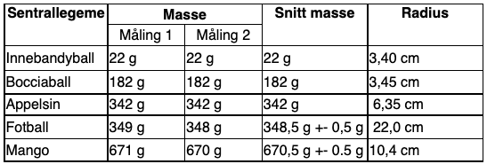

**Sett 1: Undersøkelser av ulike masser sin påvirkning.**

```python
from IPython.display import Video
Video("./vllo.mp4",width=850, height=500)
```

[video not shown]

**Sett 2: Resultater fra undersøkelse av sentrallegemets radius sin påvirkning.**

```python
from IPython.display import Video
Video("./vllo_2.mp4",width=850, height=500)
```

[video not shown]

**Utregning av krumningsvinkel**

[figure not shown]

Bilde 8: Markinger av utslagspunktene til klinkekulen.

Skråplanets avstand fra kanten av lakenet er $52,5cm$. Bruker dette som nullpunkt ved måling av utslagspunket fra de ulike sentrallegemene.

[figure not shown]

**Diskusjon**

Resultatene gir en visuell representasjon av hvordan lys kan krummes rundt massive objekter. I denne modellen fungerer lakenet på samme måte som tidrommet, der sentrallegemet i midten av lakenet danner krumninger. Klinkekulen som sendes ut på lakenet kan representere fotoner, og resultatene viser at klinkekulen krummes rundt sentrallegemet, på samme måte som lys. Utregningen av krumningsvinkelen, basert på resultatene, viser også at sentrallegemets masse påvirker graden av avbøying. Av utvalgte sentrallegemer hadde mangoen størst masse og størst krumningsvinkel, mens innebandyballen hadde minst masse og hadde en krumningsvinkel på tilnærmet 0 grader. Innebandyballen blir et eksempel på et himmellegeme som ikke har høy nok masse, og dermed ikke et stort nok gravitasjonsfelt til å utgjøre en forskjell i krumningen av lyset. De andre sentrallegemene vil representere himmellegemer med større gravitasjonsfelt som vil krumme lyset.

Videre viser resultatene at det kun er massen til sentrallegemet som påvirker tidrommet. Innebandyballen og bocciaballen har lik radius, men ulik masse, mens appelsinen og fotballen har ulik radius, men lik masse. Resultatene viser at krumningsvinkelen til innebandyballen og bocciaballen blir ulik, grunnet deres forskjell i masse. Den generelle relativitetsteorien sier at jo større masse et sentrallegeme har, desto mer påvirkning vil den ha på tidrommet. Resultatene viser at bocciaballen, med størst masse, har en større påvirkning på klinkekulens bane enn det innebandyballen har. Bocciaballen krummer altså lakenet i større grad enn innebandyballen. Resultatene viser også at appelsinen og fotballens forskjell i radius ikke har en påvirkning på klinkekulens avbøying, da de har en lik utregnet krumningsvinkel. Dette kommer av at de har lik masse. Resultatene viser dermed at radiusen til sentrallegemene ikke vil spille en rolle i krumningen av lyset.

Forsøket som er blitt gjennomført vil gi en forenklet visuell representasjon av Einsteins generelle relativitetsteori. I virkeligheten vil det være flere faktorer som påvirker situasjonen. Lakenet og legemene vil visualisere situasjonen i to romlige dimensjoner, mens det i virkeligheten vil oppleves i fire dimensjoner – tre romlige og en i tid. I tillegg har klinkekulen masse, mens fotoner er masseløse. Klinkekulen vil dermed skape en viss krumning i lakenet, noe fotoner ikke vil gjøre i tidrommet. Til tross for dette vil modellen gi et godt bilde på hvordan lyset kan påvirkes av masse.

Under utførelsen av forsøket er det flere feilkilder som må tas i betraktning. Lakenet vil for eksempel kunne bli strekt ut etter flere gjennomførte målinger, noe som gjør at sidelengen vil kunne variere. Denne feilkilden tas hensyn til i den absolutte usikkerheten til lengden, og den relative usikkerheten til krumningsvinkelen. Det er også nødvendig med en absolutt usikkerhet i de gjennomsnittlige massene til fotballen og mangoen, ettersom de to vektene som ble brukt målte ulike resultater. I tillegg vil det være ulike måleusikkerheter knyttet til utstyret som ble brukt i forsøket, for eksempel målebåndet ved målingene av markeringene på lakenet. Denne usikkerheten vil ikke ha en stor innvirkning på resultatene, da hovedformålet med forsøket er å visualisere krumningen av lyset.

**Konklusjon**

Forskningsspørsmålet som ble undersøkt i denne oppgaven var: “Hvordan påvirker masse og tidrom lyset?” Einsteins generelle relativitetsteori redefinerer gravitasjonsteorien og sier at gravitasjon ikke er en kraft, men heller en geometrisk egenskap ved tidrommet. Gravitasjon oppstår når massive objekter krummer tidrommet rundt seg og legemer som kommer inn i objektets gravitasjonsfelt vil følge denne krummingen. Dette vil også skje med lyset. Resultatene fra visualiseringen av dette konseptet viste at jo større masse sentrallegemet har, desto større vil krumningen være. Det ble også bevist at sentrallegemets radius ikke vil ha noen innvirkning for legemets påvirkning på tidrommet. Dersom massen til sentrallegemet er for liten vil krumningsvinkelen være minimal. Resultatene har dermed vist Einsteins generelle relativitetsteori, og modellen presentert i oppgaven viser hvordan legemer av stor masse krummer tidrommet og videre lysets bane.

**Kilder**

Andersen, E. P., 2020. Gravitasjon er krummet tid og rom. Tilgjengelig fra: https://titan.uio.no/blogg/2020/gravitasjon-er-krummet-tid-og-rom (Hentet 01.12.22).

Buanes, T., 2015. Jo, du kan forstå relativitetsteorien. Tilgjengelig fra: https://www.bt.no/nyheter/lokalt/i/5Lnp1/jo-du-kan-forstaa-relativitetsteorien (Hentet 01.12.22).

Buchen, L., 2009. May 29, 1919: A Major Eclipse, Relatively Speaking. Tilgjengelig fra: https://www.wired.com/2009/05/dayintech-0529/ (Hentet 01.12.22).

Callin, P. et al., 2022. Ergo Fysikk 2. 3 red. Skien: Aschehaug og Co.